# Ranking de Reclamações do Banco Central

## Introdução

O desenvolvimento do projeto foi para avaliação da Pós-Graduação MBA em Data Science, disciplina Analise Exploratoria de Dados. Utilizamos a linguagem de programação R, com as bibliotecas para criação de relatorios “rmarkdown” e graficos interativos “shiny”.

## Banco de Dados

Para aplicar os conhecimentos, utilizamos os dados do Ranking de Reclamações coletados no Banco Central do Brasil do 4º semestre de 2022. Os dados divulgados nas listagens do ranking estão disponíveis para download no site https://www.bcb.gov.br/ranking/index.asp .

O Ranking de Reclamações contribui para a transparência das ações do Banco Central do Brasil, trazendo ao conhecimento da sociedade o perfil das reclamações que foram processadas, analisadas e encerradas pelo BCB.

O Ranking é formado a partir das reclamações do público registradas nos canais de atendimento do Banco Central (BC): internet, correspondência, presencialmente ou telefone (145). As demandas são analisadas de forma amostral pelo BC.

Participam do Ranking: bancos (comerciais, múltiplos, cooperativos, de investimentos), sociedades de crédito, financiamento e investimento (SCFI), instituições de pagamento e administradoras de consórcio.

As principais Reclamações registradas são irregularidades em operações e serviços de cartões de crédito e em serviços de crédito.

### Seleção de variáveis

- Instituição financeira: bancos (comerciais, múltiplos, cooperativos, de investimentos), sociedades de crédito, financiamento e investimento (SCFI), instituições de pagamento e administradoras de consórcio.
- Reclamações reguladas procedentes: casos em que houve sinal de descumprimento de lei ou norma pela instituição financeira no período indicado.
- Total de reclamações: total de reclamações reguladas procedentes, reclamações reguladas outras e reclamações não reguladas.
- Total de clientes : O número de clientes é formado pela base conjugada de dados das instituições no Cadastro de Clientes do Sistema Financeiro Nacional (CCS) e no Sistema de Informações de Crédito do Banco Central (SCR), em nº de CPFs e CNPJs distintos. Os clientes são contados uma única vez por instituição ou conglomerado financeiro.
- Índice : (reclamações reguladas procedentes * 1.000.000) / número de clientes.
- Razão de reclamação: Criaremos a variável utilizando o total de (reclamações procedentes / total de reclamações) * 100 .

  As instituições são classificadas pela ordem decrescente do índice de reclamações, ou seja, da mais reclamada para a menos reclamada. É possível consultar a relação de instituições que tiveram menos de trinta reclamações procedentes apresentada em ordem alfabética do nome.

### Ambiente RStudio e Bibliotecas utilizadas

[figure not shown]

```r
library(corrplot)
library(dlookr)
library(dplyr)
library(ggplot2)
library(readxl)
library(summarytools)
library(tidyverse)
library(knitr)
library(stringr)
library(writexl)
library(rstatix)
library(ggpubr)
library(patchwork)
library(psych)
library(ggcorrplot)
library(GGally)
library(mice)
library(skimr)
```

### Carregando o Banco de Dados

–

Utilizamos o github para download do arquivo baixado do Banco Central e a função read_excel() para criar o Banco de dados Bancos3 com os dados do arquivo Bancos4.xlsx.

```r
download.file( url = "https://github.com/taianasantos/analise/blob/main/Bancos.xlsx?raw=true", quiet = TRUE,  mode = "wb", destfile = "Bancos4.xlsx" )

Bancos <- readxl :: read_excel("Bancos4.xlsx")
```

–

```r
knitr :: kable(head(Bancos), digits = 1 ,"pipe")
```

| Instituicao | Indice | Procedentes | Total_Reclamacoes | Clientes | Razao |
| --- | --- | --- | --- | --- | --- |
| ACESSO SOLUÇÕES DE PAGAMENTO S.A. - INSTITUIÇÃO DE PAGAMENTO | 15.5 | 86 | 179 | 5538591 | 48.0 |
| AGIBANK (conglomerado) | 112.4 | 224 | 545 | 1992640 | 41.1 |
| AME DIGITAL BRASIL INSTITUICAO DE PAGAMENTO LTDA | 1.3 | 40 | 92 | 31101626 | 43.5 |
| BANCO CSF S.A. | 6.3 | 51 | 165 | 8070375 | 30.9 |
| BANCO DIGIMAIS S.A. | 170.3 | 56 | 141 | 328722 | 39.7 |
| BANCO DO ESTADO DO PARÁ S.A. | 33.7 | 34 | 65 | 1009445 | 52.3 |

### Identificando os tipos de cada variável

–

Utilizamos a função diagnose() ,biblioteca dlookr, para identificar as variáveis para análise.

A função diagnose() do pacote dlookr que retorna por variável qual o tipo dela, contagem de valores faltantes, frequência de faltantes em relação à base toda.

```r
Bancos %>% dlookr::diagnose()
```

```
## # A tibble: 6 × 6
##   variables         types     missing_count missing_percent unique_count uniqu…¹
##   <chr>             <chr>             <int>           <dbl>        <int>   <dbl>
## 1 Instituicao       character             0               0           42   1
## 2 Indice            numeric               0               0           42   1
## 3 Procedentes       numeric               0               0           39   0.929
## 4 Total_Reclamacoes numeric               0               0           42   1
## 5 Clientes          numeric               0               0           42   1
## 6 Razao             numeric               0               0           42   1
## # … with abbreviated variable name ¹unique_rate
```

# Análise descritiva da Base de dados

Para realizar essa análise, podemos utilizar a função descr do pacote summarytools e realizar a leitura desses dados. Analisar a centralidade dos dados, dipersão, assimetria e se há presença de outliers.

```r
Bancos  %>% summarytools::descr()
```

```
## Non-numerical variable(s) ignored: Instituicao
```

```
## Descriptive Statistics
## Bancos
## N: 42
##
##                         Clientes   Indice   Procedentes    Razao   Total_Reclamacoes
## ----------------- -------------- -------- ------------- -------- -------------------
##              Mean    21821567.14    69.91        418.57    38.43             1294.95
##           Std.Dev    33082609.72   124.29        539.46    13.13             1848.89
##               Min      179473.00     1.28         30.00     8.62               65.00
##                Q1     1992640.00    11.75         53.00    28.34              165.00
##            Median     6800159.50    23.66        185.00    39.26              462.00
##                Q3    23219194.00    63.88        652.00    48.04             1711.00
##               Max   148128348.00   638.66       2225.00    70.66             6878.00
##               MAD     8675307.14    23.80        217.94    15.53              485.55
##               IQR    20938345.00    50.85        587.75    19.46             1541.00
##                CV           1.52     1.78          1.29     0.34                1.43
##          Skewness           2.08     3.04          1.73    -0.01                1.86
##       SE.Skewness           0.37     0.37          0.37     0.37                0.37
##          Kurtosis           3.95     9.50          2.22    -0.41                2.35
##           N.Valid          42.00    42.00         42.00    42.00               42.00
##         Pct.Valid         100.00   100.00        100.00   100.00              100.00
```

```r
view(descr(Bancos))
```

As variaveis Clientes, Indice, Procedentes e Total_Reclamacoes apresentam presenças de outliers, influenciando muito o valor da média que apresenta valores maiores que a Mediana. Com o valor de desvio padrão mais alto indica maior dispersão nos dados, geralmente longe da média.

# Distribuição Normal

A distribuição normal é uma das mais utilizadas em estatística sendo exigida em muitas situações pelas suas boas propriedades matemáticas e por isso é tão utilizada em probabilidade e estatística, como no teste t e na ANOVA.

Para verificar a normalidade da distribuição vamos apresentar três ferramentas que devem ser utilizadas em conjunto:

1. Histograma: É uma distribuição contínua, onde a distribuição de frequências de uma variável quantitativa apresenta a forma de sino e é simétrica em relação a sua média.

   Algumas caracteristicas:

   É simétrica em torno da média;

   A área sob a curva corresponde à proporção 1 ou 100%;

   As medidas de tendência central (média, mediana e moda) apresentam o mesmo valor;

   Os extremos da curva tendem ao infinito em ambas as direções e, teoricamente, jamais tocam o eixo x;

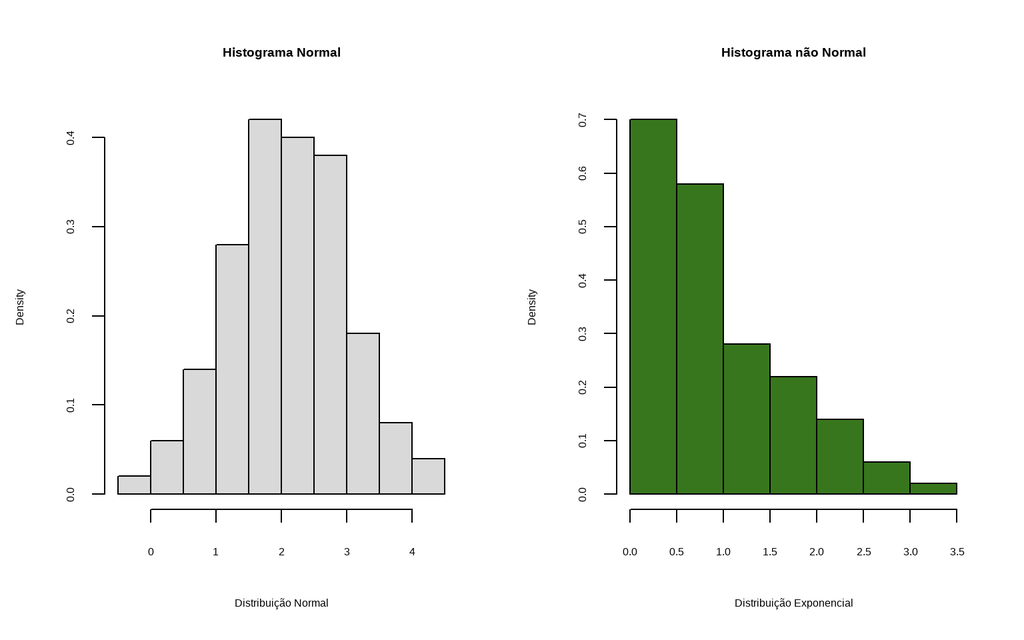

```r
  set.seed(1)
    dds.normal <- rnorm(100,2,1) #Normal
    dds.exp <- rexp(100)  # Exponencial
    # Histogramas

    par(mfrow=c(1,2))

    hist(dds.normal,
         col = "#D9D9D9",
         freq = F,
         main = "Histograma Normal", xlab = "Distribuição Normal")
    #curve(dnorm(x, mean = mean(dds.normal), sd = sd(dds.normal)), add = T)

    hist(dds.exp,
         col = "#38761D",
         freq = F,
         main = "Histograma não Normal", xlab = "Distribuição Exponencial")
```

2. QQ-plot : grafico utilizado para comprar quartil por quartil entre uma distribuição normal padrão e a distribuição que se visa comparar após ser padronizada. Caso o Q-Q Plot tenha comportamento comportamento de uma reta perfeitamente ascendente, é a sinalização de que a distribuição que está estudando se aproxima de uma distribuição normal. No entanto, caso perceba muita variação, sobretudo nos extremos, terá a sinalização de que a distribuição estudada não é normal.

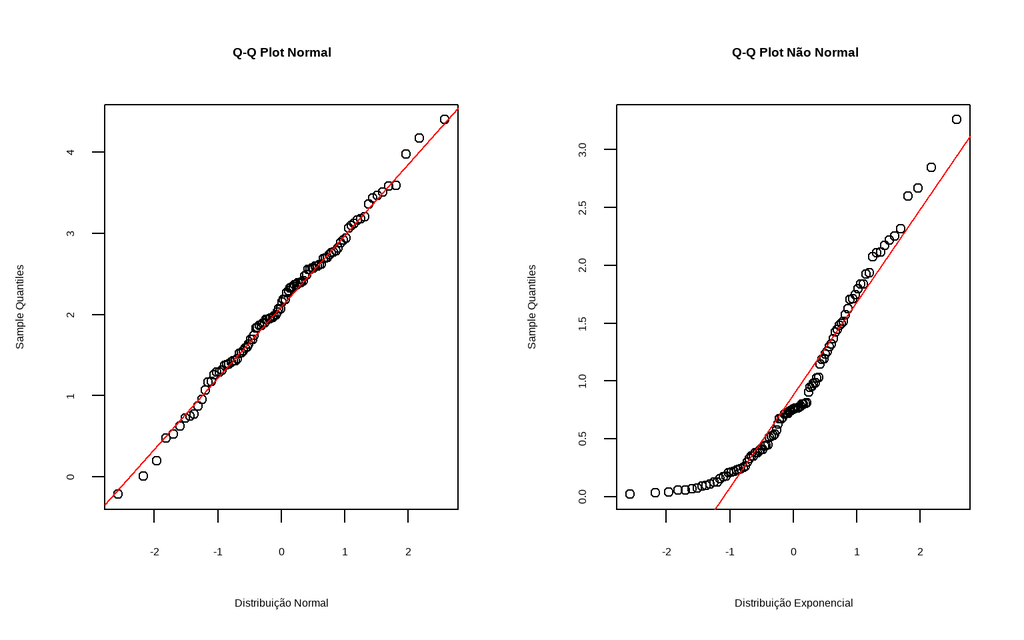

   ```r
   par(mfrow=c(1,2))

   # Se os pontos se concentrarem em torno de uma linha reta, # então temos indícios de que a distribuição é normal.
   qqnorm(dds.normal, main = "Q-Q Plot Normal", xlab = "Distribuição Normal")
   qqline(dds.normal, col = "red")

   qqnorm(dds.exp, main = " Q-Q Plot Não Normal", xlab = "Distribuição Exponencial")
   qqline(dds.exp, col = "red")
   ```

3. Teste Shapiro-Wilk;

   Se p- value > 0,05, então a distribuição dos dados fornecidos não difere significativamente da distribuição normal. Se p-value < 0.05, então está rejeitada a hipótese de distribuição normal.

```r
rstatix:: shapiro_test(dds.normal) # normal
```

```
## # A tibble: 1 × 3
##   variable   statistic p.value
##   <chr>          <dbl>   <dbl>
## 1 dds.normal     0.996   0.988
```

```r
rstatix:: shapiro_test(dds.exp) # não normal
```

```
## # A tibble: 1 × 3
##   variable statistic    p.value
##   <chr>        <dbl>      <dbl>
## 1 dds.exp      0.915 0.00000776
```

# Normalidade das variáveis

Utilizando a função pairs.panels e com a analise rapida dos histogramas, possivelmente a unica variavel com distribuição normal é a razão.

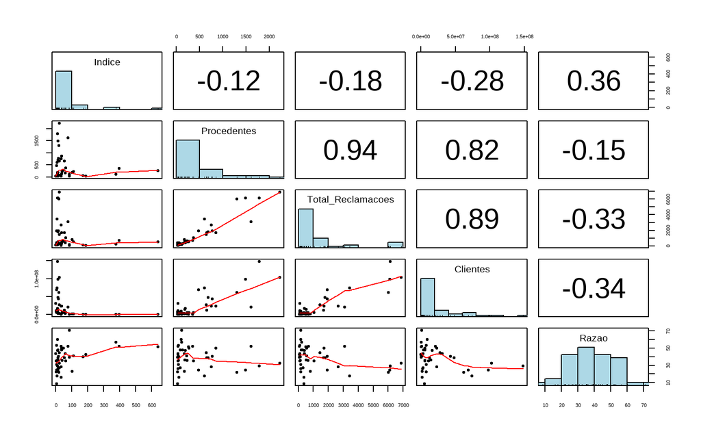

```r
psych:: pairs.panels(Bancos[, -1],
             method = "pearson", # correlation method
             hist.col = "lightblue",
            density = FALSE,  # show density plots
             ellipses = FALSE # show correlation ellipses
             )
```

## Número de Bins

A escolha do número de bins do histograma é uma escolha arbitrária e está diretamente ligada à amplitude que se deseja definir como base de cada barra contígua, para o caso onde se trabalha com amplitudes iguais para todos intervalos.

Existem equações modeladas para sugerir amplitudes dos bins de modo a facilitar a decisão do analista, das quais destacamos duas:

A regra de Freedman-Diaconis leva em consideração o intervalo interquartil dos dados, que impede que outliers tenham infuência na definição da amplitude do intervalo de bin.

```r
fd <- function(x) {
  n <-length(x)
  return((2*IQR(x))/n^(1/3))
}
sr <- function(x) {
  n <-length(x)
  return((3.49*sd(x))/n^(1/3))
  }
```

# Variavel Indice

## Distribuição Não Normal

### Histograma

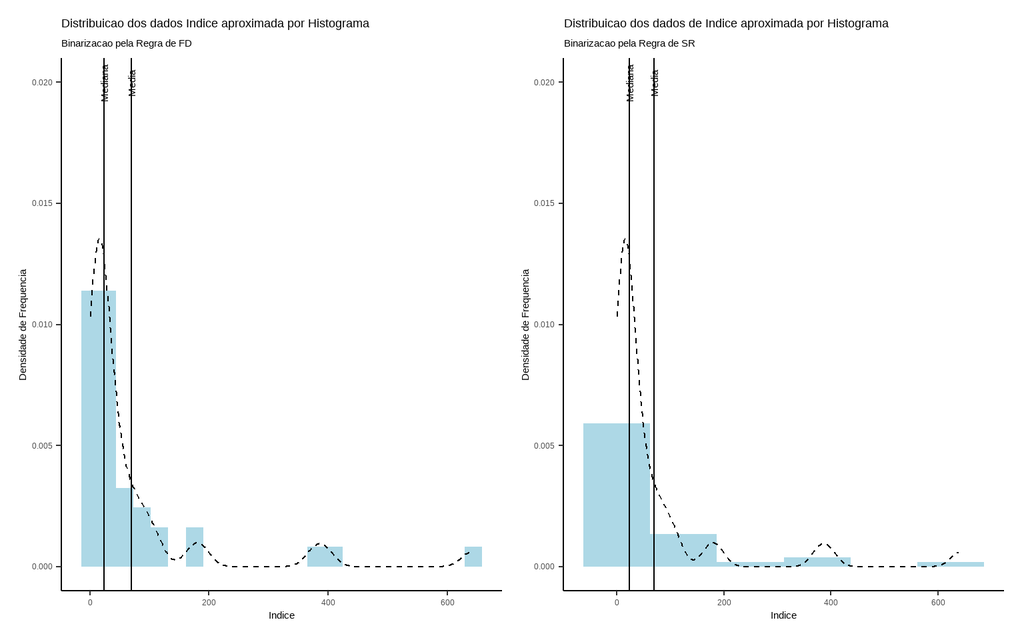

```r
g1 <- Bancos %>% dplyr::select(Indice) %>% ggplot(aes(x=Indice))+geom_histogram(aes(y = after_stat(density)) , binwidth=fd, fill = 'lightblue') + xlab('Indice') + ylab('Densidade de Frequencia') + labs(title = "Distribuicao dos dados Indice aproximada por Histograma", subtitle = "Binarizacao pela Regra de FD") + geom_vline(xintercept=c(median(Bancos$Indice), mean(Bancos$Indice))) + annotate("text", x=median(Bancos$Indice) + 0.3, y=0.02, label="Mediana", angle=90) + annotate("text", x=mean(Bancos$Indice) + 0.3, y=0.02, label="Media", angle=90) + geom_density(linetype = 2) + theme_classic()


g2 <- Bancos %>% dplyr::select(Indice) %>% ggplot(aes(x=Indice))+geom_histogram(aes(y = after_stat(density)) , binwidth=sr, fill = 'lightblue') + xlab('Indice') + ylab('Densidade de Frequencia') + labs(title = "Distribuicao dos dados de Indice aproximada por Histograma", subtitle = "Binarizacao pela Regra de SR") + geom_vline(xintercept=c(median(Bancos$Indice), mean(Bancos$Indice))) + annotate("text", x=median(Bancos$Indice) + 0.3, y=0.02, label="Mediana", angle=90) + annotate("text", x=mean(Bancos$Indice) + 0.3, y=0.02, label="Media", angle=90) + geom_density(linetype = 2) + theme_classic()

g1 + g2
```

### Qq Plot

Grafico Qqplot

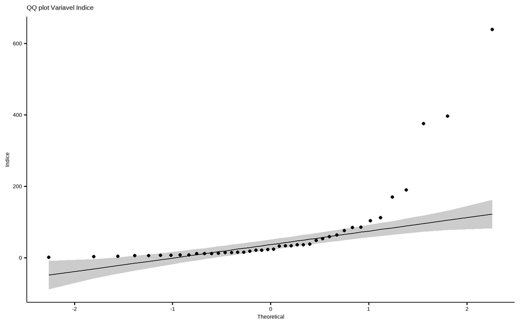

```r
ggpubr::ggqqplot(Bancos$Indice)  +
 labs(title="QQ plot Variavel Indice",
       y = "Indice")
```

### Teste Shapiro-Wilk

```r
rstatix::shapiro_test(Bancos$Indice)
```

```
## # A tibble: 1 × 3
##   variable      statistic  p.value
##   <chr>             <dbl>    <dbl>
## 1 Bancos$Indice     0.544 3.12e-10
```

# Variavel Procedentes

## Resultado: Distribuição Não Normal

### Histograma

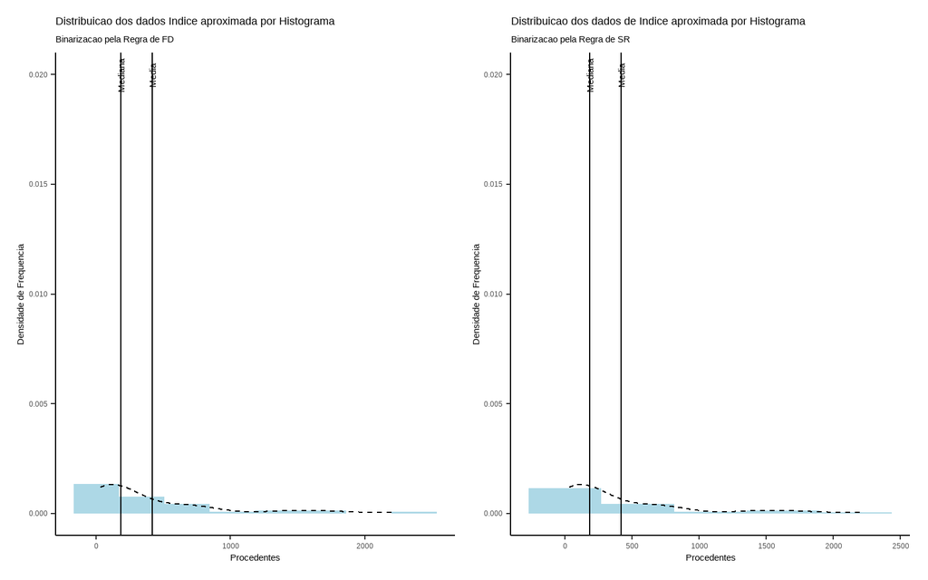

```r
g1 <- Bancos %>% dplyr::select(Procedentes) %>% ggplot(aes(x=Procedentes))+geom_histogram(aes(y = after_stat(density)) , binwidth=fd, fill = 'lightblue') + xlab('Procedentes') + ylab('Densidade de Frequencia') + labs(title = "Distribuicao dos dados Indice aproximada por Histograma", subtitle = "Binarizacao pela Regra de FD") + geom_vline(xintercept=c(median(Bancos$Procedentes), mean(Bancos$Procedentes))) + annotate("text", x=median(Bancos$Procedentes) + 0.3, y=0.02, label="Mediana", angle=90) + annotate("text", x=mean(Bancos$Procedentes) + 0.3, y=0.02, label="Media", angle=90) + geom_density(linetype = 2) + theme_classic()


g2 <- Bancos %>% dplyr::select(Procedentes) %>% ggplot(aes(x=Procedentes))+geom_histogram(aes(y = after_stat(density)) , binwidth=sr, fill = 'lightblue') + xlab('Procedentes') + ylab('Densidade de Frequencia') + labs(title = "Distribuicao dos dados de Indice aproximada por Histograma", subtitle = "Binarizacao pela Regra de SR") + geom_vline(xintercept=c(median(Bancos$Procedentes), mean(Bancos$Procedentes))) + annotate("text", x=median(Bancos$Procedentes) + 0.3, y=0.02, label="Mediana", angle=90) + annotate("text", x=mean(Bancos$Procedentes) + 0.3, y=0.02, label="Media", angle=90) + geom_density(linetype = 2) + theme_classic()

g1 + g2
```

### Qq Plot

Grafico Qqplot

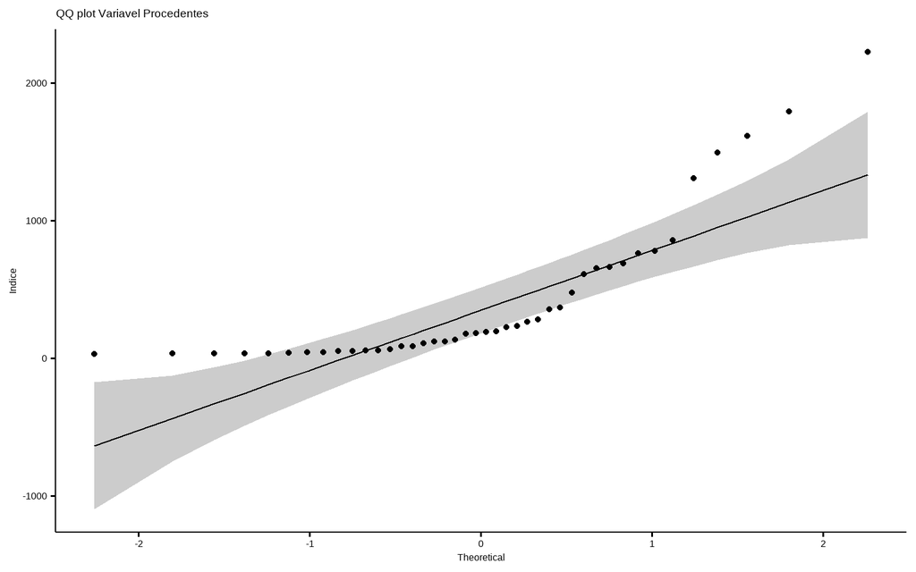

```r
ggpubr::ggqqplot(Bancos$Procedentes)  +
 labs(title="QQ plot Variavel Procedentes",
       y = "Indice")
```

### Teste Shapiro-Wilk

```r
rstatix::shapiro_test(Bancos$Procedentes)
```

```
## # A tibble: 1 × 3
##   variable           statistic     p.value
##   <chr>                  <dbl>       <dbl>
## 1 Bancos$Procedentes     0.731 0.000000196
```

# Variavel Total_Reclamacoes

## Distribuição Não Normal

### Histograma

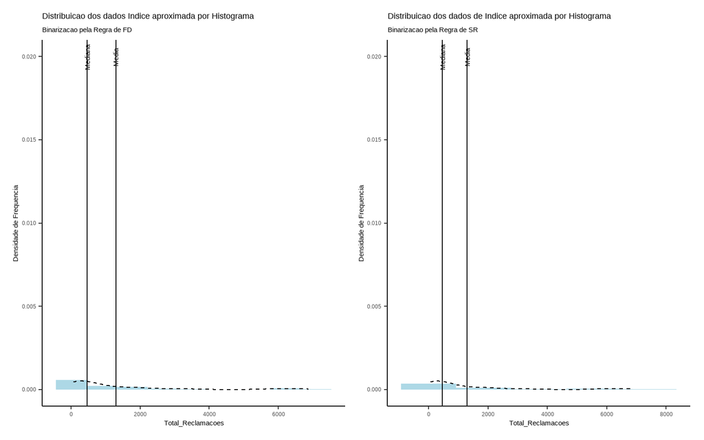

```r
g1 <- Bancos %>% dplyr::select(Total_Reclamacoes ) %>% ggplot(aes(x=Total_Reclamacoes ))+geom_histogram(aes(y = after_stat(density)) , binwidth=fd, fill = 'lightblue') + xlab('Total_Reclamacoes ') + ylab('Densidade de Frequencia') + labs(title = "Distribuicao dos dados Indice aproximada por Histograma", subtitle = "Binarizacao pela Regra de FD") + geom_vline(xintercept=c(median(Bancos$Total_Reclamacoes ), mean(Bancos$Total_Reclamacoes ))) + annotate("text", x=median(Bancos$Total_Reclamacoes ) + 0.3, y=0.02, label="Mediana", angle=90) + annotate("text", x=mean(Bancos$Total_Reclamacoes ) + 0.3, y=0.02, label="Media", angle=90) + geom_density(linetype = 2) + theme_classic()


g2 <- Bancos %>% dplyr::select(Total_Reclamacoes ) %>% ggplot(aes(x=Total_Reclamacoes ))+geom_histogram(aes(y = after_stat(density)) , binwidth=sr, fill = 'lightblue') + xlab('Total_Reclamacoes ') + ylab('Densidade de Frequencia') + labs(title = "Distribuicao dos dados de Indice aproximada por Histograma", subtitle = "Binarizacao pela Regra de SR") + geom_vline(xintercept=c(median(Bancos$Total_Reclamacoes ), mean(Bancos$Total_Reclamacoes ))) + annotate("text", x=median(Bancos$Total_Reclamacoes ) + 0.3, y=0.02, label="Mediana", angle=90) + annotate("text", x=mean(Bancos$Total_Reclamacoes ) + 0.3, y=0.02, label="Media", angle=90) + geom_density(linetype = 2) + theme_classic()

g1 + g2
```

### Qq Plot

Grafico Qqplot

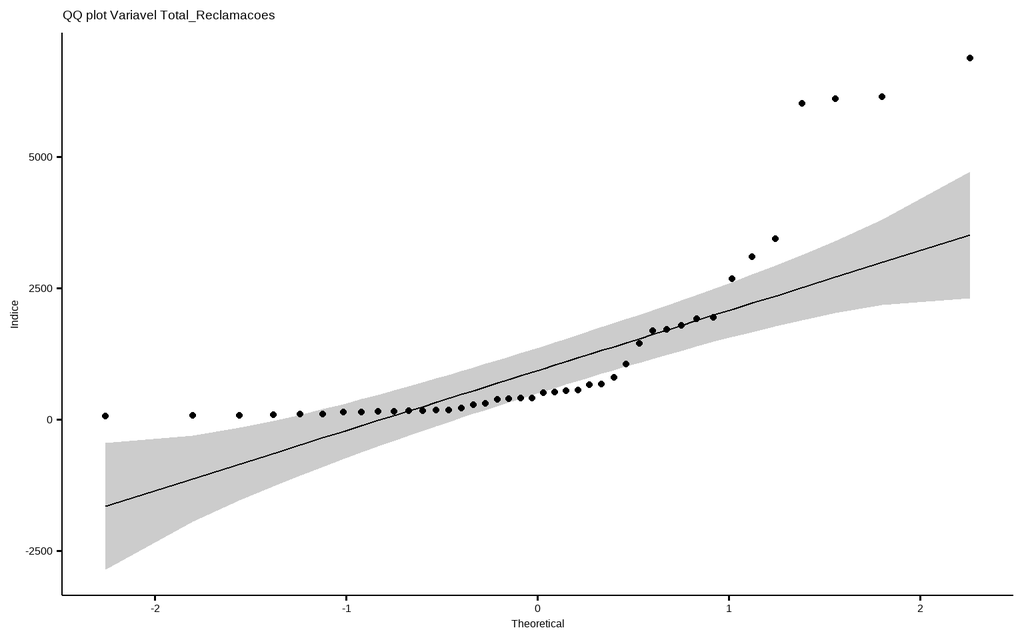

```r
ggpubr::ggqqplot(Bancos$Total_Reclamacoes )  +
 labs(title="QQ plot Variavel Total_Reclamacoes ",
       y = "Indice")
```

### Teste Shapiro-Wilk

```r
rstatix::shapiro_test(Bancos$Total_Reclamacoes)
```

```
## # A tibble: 1 × 3
##   variable                 statistic      p.value
##   <chr>                        <dbl>        <dbl>
## 1 Bancos$Total_Reclamacoes     0.671 0.0000000193
```

# Variavel Clientes

## Distribuição Não Normal

### Histograma

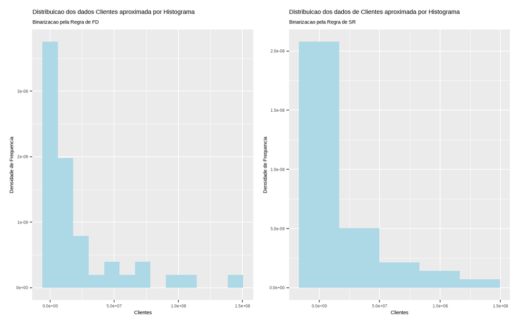

```r
g1 <- Bancos %>% dplyr::select(Clientes) %>% ggplot(aes(x=Clientes))+geom_histogram(aes(y = after_stat(density)) , binwidth=fd, fill = 'lightblue') + xlab('Clientes') + ylab('Densidade de Frequencia') + labs(title = "Distribuicao dos dados Clientes aproximada por Histograma", subtitle = "Binarizacao pela Regra de FD")
#+ geom_vline(xintercept=c(median(Bancos$Clientes), mean(Bancos$Clientes))) + annotate("text", x=median(Bancos$Clientes) + 0.3, y=0.02, label="Mediana", angle=90) + annotate("text", x=mean(Bancos$Clientes) + 0.3, y=0.02, label="Media", angle=90) + geom_density(linetype = 2) + theme_classic()


g2 <- Bancos %>% dplyr::select(Clientes) %>% ggplot(aes(x=Clientes))+geom_histogram(aes(y = after_stat(density)) , binwidth=sr, fill = 'lightblue') + xlab('Clientes') + ylab('Densidade de Frequencia') + labs(title = "Distribuicao dos dados de Clientes aproximada por Histograma", subtitle = "Binarizacao pela Regra de SR")

#+ geom_vline(xintercept=c(median(Bancos$Clientes), mean(Bancos$Clientes))) + annotate("text", x=median(Bancos$Clientes) , y=0.02, label="Mediana", angle=90) + annotate("text", x=mean(Bancos$Clientes) , y=0.02, label="Media", angle=90) + geom_density(linetype = 2) + theme_classic()

g1 + g2
```

### Qq Plot

Grafico Qqplot

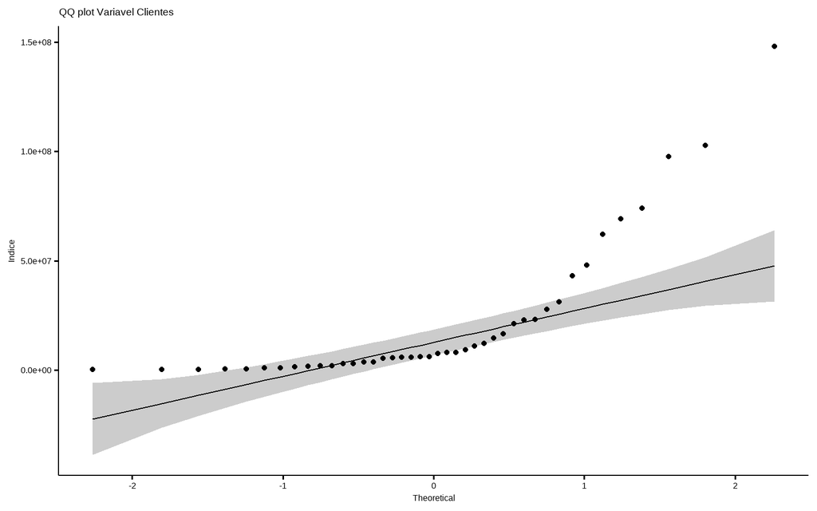

```r
ggpubr::ggqqplot(Bancos$Clientes)  +
 labs(title="QQ plot Variavel Clientes",
       y = "Indice")
```

### Teste Shapiro-Wilk

```r
rstatix::shapiro_test(Bancos$Clientes)
```

```
## # A tibble: 1 × 3
##   variable        statistic      p.value
##   <chr>               <dbl>        <dbl>
## 1 Bancos$Clientes     0.676 0.0000000234
```

# Variaveis Razao

## Distribuição Normal

### Histogramas

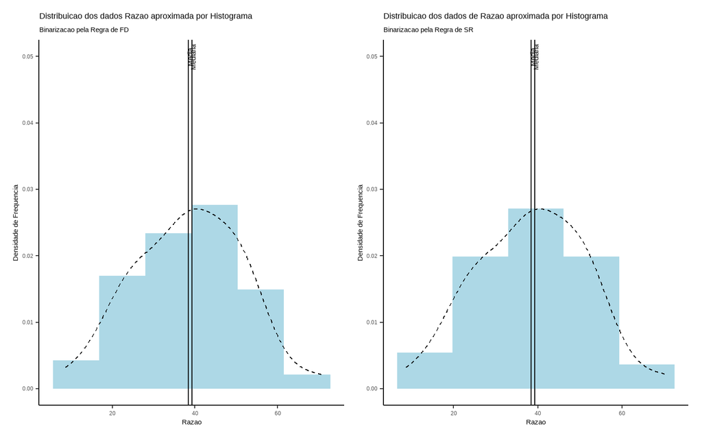

```r
g1 <- Bancos %>% dplyr::select(Razao) %>% ggplot(aes(x=Razao))+geom_histogram(aes(y = after_stat(density)) , binwidth=fd, fill = 'lightblue') + xlab('Razao') + ylab('Densidade de Frequencia') + labs(title = "Distribuicao dos dados Razao aproximada por Histograma", subtitle = "Binarizacao pela Regra de FD") + geom_vline(xintercept=c(median(Bancos$Razao), mean(Bancos$Razao))) + annotate("text", x=median(Bancos$Razao) + 0.3, y=0.05, label="Mediana", angle=90) + annotate("text", x=mean(Bancos$Razao) + 0.3, y=0.05, label="Media", angle=90) + geom_density(linetype = 2) + theme_classic()


g2 <- Bancos %>% dplyr::select(Razao) %>% ggplot(aes(x=Razao))+geom_histogram(aes(y = after_stat(density)) , binwidth=sr, fill = 'lightblue') + xlab('Razao') + ylab('Densidade de Frequencia') + labs(title = "Distribuicao dos dados de Razao aproximada por Histograma", subtitle = "Binarizacao pela Regra de SR") + geom_vline(xintercept=c(median(Bancos$Razao), mean(Bancos$Razao))) + annotate("text", x=median(Bancos$Razao) + 0.3, y=0.05, label="Mediana", angle=90) + annotate("text", x=mean(Bancos$Razao) + 0.3, y=0.05, label="Media", angle=90) + geom_density(linetype = 2) + theme_classic()

g1 + g2
```

### QQPLOT

Grafico Qqplot

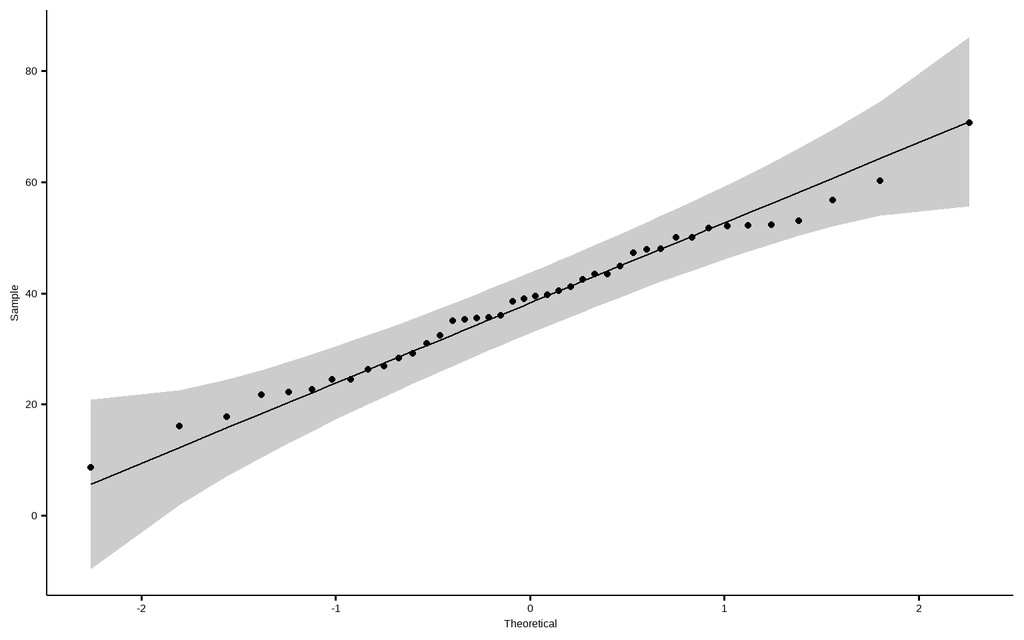

```r
ggpubr::ggqqplot(Bancos$Razao)
```

### Shapiro-Wilk Normality Test

```r
rstatix::shapiro_test(Bancos$Razao)
```

```
## # A tibble: 1 × 3
##   variable     statistic p.value
##   <chr>            <dbl>   <dbl>
## 1 Bancos$Razao     0.991   0.977
```

# Coeficiente de Correlação

–

Na estatística o coeficiente de correlação de Pearson (r) mede a relação que existe entre duas variáveis dentro de uma mesma escala métrica.

A função do coeficiente de correlação é determinar qual é a intensidade da relação que existe entre conjuntos de dados ou informações conhecidas.

O valor do coeficiente de correlação pode variar entre -1 e 1. Para interpretar o coeficiente é preciso saber que 1 significa que a correlação entre as variáveis é perfeita positiva e -1 significa que é perfeita negativa. Se o coeficiente for igual a 0 significa que as variáveis não dependem uma da outra.

### Correlograma

–

Utilizamos a função corrplot() para criar uma visualização grafica da matrix de correlação.

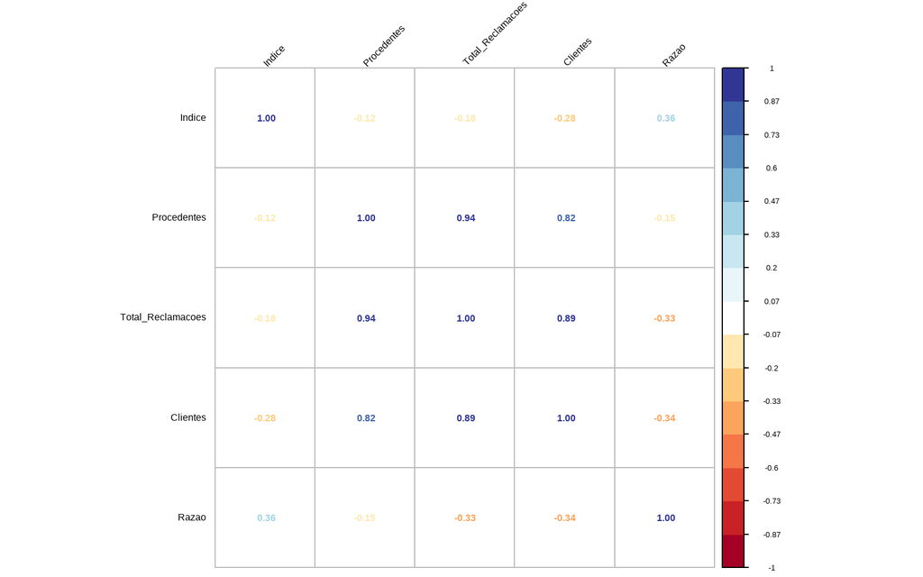

```r
corrplot :: corrplot(cor(Bancos[, -1]), method='number', , tl.col = 'black', cl.ratio = 0.2, tl.srt = 45, col = COL2('RdYlBu', 15))
```

As maiores coorelação são entre o total de quantidade de clientes, reclamações recebidas e reclamações procedentes.

# Scatterplot Matrix

```r
#create
ggpairs(Bancos[, -1])
```

[output not shown]

# Regressão linear

A correlação é uma relação entre duas variáveis, sendo a primeira dependente e a segunda independente. A análise da correlação tem o objetivo de atestar se existe uma relação de dependência significativa entre duas variáveis, é feito através do coeficiente de correlação, variando de – 1 a 1, com -1 correlação linear negativa, 0 nenhuma correlação e 1 correlação linear positiva.

Um exemplo em que se pode utilizar o princípio da correlação, um gerente de recursos humanos deseja saber se existe ligação entre o número de horas de treinamento de um funcionário e o número de reclamações que o funcionário recebeu. Caso haja correlação linear positiva, quer dizer que quanto mais horas de treinamento se gasta com funcionários, menos reclamações. Nesse caso, a variável independente é a quantidade de horas de treinamento para o funcionário, e a variável dependente é o número de reclamações.

A análise de regressão linear pode ser feita após a garantia de correlação linear entre duas variáveis, busca encontrar a reta que melhor modela, compensando-se os resíduos, a correlação entre as variáveis envolvidas, e essa reta pode ser utilizada para fazer previsões de valores da variável dependente a partir de valores da variável independente. O mesmo exemplo sobre o treinamento de funcionários e número de reclamações valem também para a regressão linear, a “saída” da regressão linear seria uma função que expressaria da melhor maneira a relação entre os valores das variáveis envolvidas.

Para concluir, a análise de correlação junto com a regressão linear têm por objetivo maior inferir se há relação entre duas variáveis com base em um conjunto de dados anterior, e com base nessa inferência, caso positiva para que haja de fato relação, seja possível obter uma função que relaciona uma variável a outra para que se possa prever valores futuros para a variável dependente com base em valores da variável independente. A diferença entre a correlação e regressão linear é que a 2ª obtém uma função da relação que melhor a expressa, enquanto que a 1ª indica se há relação.

Regressão linear é o método com o qual se encontra a reta que melhor descreve a relação entre os dados. A reta é criada com uma equação linear y = b + m1 * x1…mn*xn, onde b será o coeficiente linear, e m o coeficiente angular, sendo um para cada variável preditora existente nos dados.

A função que realiza o ajuste da reta ou modelo de regressão linear no R é a lm().

O comando summary() poderá indicar se os seus parâmetros estimados são significativos ou não, ou seja, se é possível assumir que são diferentes de zero.

```r
#Simples, variavel explicativa idade
modelo.1 <- lm(Procedentes ~ Clientes, data = Bancos)
summary(modelo.1, type = 'html')
```

Call: lm(formula = Procedentes ~ Clientes, data = Bancos)

Residuals: Min 1Q Median 3Q Max -571.71 -151.63 -77.27 76.13 1202.91

Coefficients: Estimate Std. Error t value Pr(>|t|)  
(Intercept) 1.276e+02 5.832e+01 2.188 0.0346 *  
Clientes 1.334e-05 1.484e-06 8.986 3.84e-11 *** — Signif. codes: 0 ‘**’ 0.001 ’**’ 0.01 ’’ 0.05 ‘.’ 0.1 ’ ’ 1

Residual standard error: 314.4 on 40 degrees of freedom Multiple R-squared: 0.6687, Adjusted R-squared: 0.6604 F-statistic: 80.74 on 1 and 40 DF, p-value: 3.842e-11

```r
modelo.1$coefficients
```

```
##  (Intercept)     Clientes
## 1.275916e+02 1.333451e-05
```

E temos a equação da reta ajustada: E(Y ) = 1.275916e+02 +1.333451e-05 ∗ Clientes

Essa função também retorna a medida R²(adjusted R-squared), que indica o quanto da variação presente nos dados está sendo explicada pela covariável.

Quanto maior o R², mais explicativo é o modelo linear, ou seja, melhor ele se ajusta à amostra. Com R² = 0.6687 significa que o modelo linear explica 66,87% da variância da variável dependente a partir do regressores (variáveis independentes) incluídas naquele modelo linear.

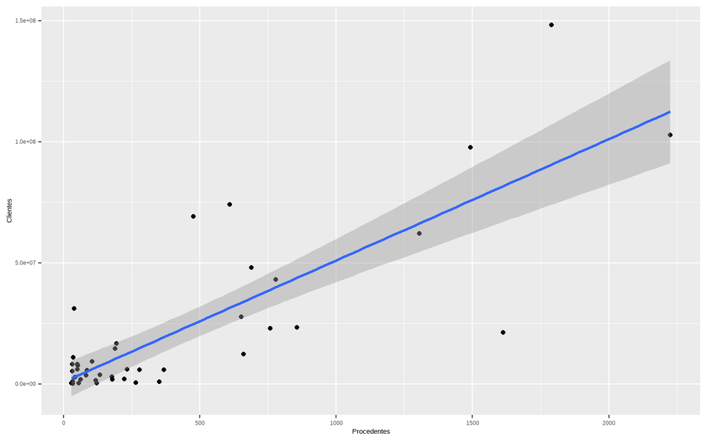

```r
ggplot(Bancos, mapping = aes(Procedentes, Clientes)) +
   geom_point() +
   geom_smooth(method = "lm")
```

# Carregando o Banco de Dados

–

```r
download.file( url = "https://github.com/taianasantos/analise/blob/main/Bancosconna.xlsx?raw=true", quiet = TRUE,  mode = "wb", destfile = "Bancos1.xlsx" )

Bancos <- readxl :: read_excel("Bancos1.xlsx")
```

# Dados Faltantes

Completude (SUBSTANTIVO) - qualidade, estado ou propriedade do que é completo, perfeito, acabado.

We should be suspicious of any dataset (large or small) which appears perfect. Tradução (“Devemos suspeitar de qualquer conjunto de dados (grande ou pequeno) que pareça perfeito.”) — David J. Hand

A definição de Completude é a qualidade, estado ou propriedade do que é completo, perfeito, acabado. No mundo ideal um conjunto de dados seria totalmente preenchido, mas na pratica é muito comum que ele não esteja totalmente preenchido, terá em algumas colunas ou linhas, valores chamados “NaN” (do inglês “Not a Number”), que são os valores faltantes.

Algumas possibilidades desses dados faltantes podem ser: perguntas não respondidas em uma entrevista, dados perdidos por coleta equivocada de registro, muitas vezes, quem estava coletando o conjunto de dados não encontrou a informação necessária; ou ainda, no momento de se transferir os dados de um lugar para outro, a informação foi perdida; enfim, há vários motivos que podem fazer com que um dado falte em uma base de dados.

Algumas Informações importantes são perdidas, correlações ficam distorcidas ou pode não ter um número satisfatório de pessoas para generalizar a situação para uma população maior.

O impacto desses dados faltantes na inferência estatística é potencialmente alto, ainda mais em alguns casos onde o público que possui dado ausente é sistematicamente diferente daquele que os dados estão completos. O simplesmente descartá-los pode levar a resultados enviesados.

## Tipos de dados faltantes?

1. Faltantes completamente aleatórios (missingnes completley at random). A probabilidade de estarem ausentes é independente de qualquer observação no banco de dados.
2. Faltantes aleatórios (missingnes at random). Os dados faltantes não respeitam uma distribuição aleatória como as amostras com dados observados.
3. Faltantes não aleatórios (missing not at random). A probabilidade é que os valores faltantes dependam não só dos dados observados assim como dos dados não observados.

É importante identificar o tipo correto de dados faltantes para não introduzir um viés aos dados e utilizar a melhor técninca para tratar os dados ausentes.

Algumas técnicas de tratamenos dos “NaN”:

1. Deletar a variável/atributo que possui dados faltantes.
2. Deletar somente as amostras com dados faltantes.
3. Preencher (fill in) os dados faltantes por alguma estatística (média, mediana, etc)
4. Modelar o dado faltante

```r
Bancos %>% dlookr::diagnose()
```

```
## # A tibble: 6 × 6
##   variables         types     missing_count missing_percent unique_count uniqu…¹
##   <chr>             <chr>             <int>           <dbl>        <int>   <dbl>
## 1 Instituicao       character             0             0            154   1
## 2 Indice            numeric             112            72.7           43   0.279
## 3 Procedentes       numeric               0             0             65   0.422
## 4 Total_Reclamacoes numeric               0             0             86   0.558
## 5 Clientes          numeric               0             0            144   0.935
## 6 Razao             numeric               0             0            102   0.662
## # … with abbreviated variable name ¹unique_rate
```

```r
sum(is.na(Bancos))
```

```
## [1] 112
```

## Imputando dados com mice

Métodos multivariados para tratamento de missing values A função mice() é utilizada para construir o modelo, que produz várias imputações (valores de substituição) para os dados ausentes, sendo o método baseado na especificação condicional, em que cada variável incompleta é imputada por um modelo separado.

Dados faltantes na Variavel Indice, quando a quantidade de reclamações procedentes é menor que 30, fantantes não aleatórios.

A função mice possui vários métodos, como por exemplo:

```r
# Realiza a imputacao mice
dadosmice <- mice(
  data = Bancos[ ,-1],
  meth = "rf"
) %>%
  complete()
skim(dadosmice)
```

Data summary

| Name | dadosmice |
| --- | --- |
| Number of rows | 154 |
| Number of columns | 5 |
| _______________________ |  |
| Column type frequency: |  |
| numeric | 5 |
| ________________________ |  |
| Group variables | None |

**Variable type: numeric**

| skim_variable | n_missing | complete_rate | mean | sd | p0 | p25 | p50 | p75 | p100 | hist |
| --- | --- | --- | --- | --- | --- | --- | --- | --- | --- | --- |
| Indice | 0 | 1 | 123.46 | 132.83 | 1.28 | 16.16 | 84.30 | 189.44 | 638.66 | ▇▅▁▁▁ |
| Procedentes | 0 | 1 | 118.44 | 334.71 | 0.00 | 1.00 | 6.00 | 33.75 | 2225.00 | ▇▁▁▁▁ |
| Total_Reclamacoes | 0 | 1 | 368.58 | 1113.80 | 1.00 | 5.00 | 19.00 | 101.50 | 6878.00 | ▇▁▁▁▁ |
| Clientes | 0 | 1 | 6314152.74 | 19631373.97 | 0.00 | 19117.00 | 304368.00 | 1885897.25 | 148128348.00 | ▇▁▁▁▁ |
| Razao | 0 | 1 | 30.24 | 23.89 | 0.00 | 10.67 | 27.17 | 47.26 | 100.00 | ▇▇▅▂▁ |

```r
# Realiza a imputacao mice
dadosmice2 <- mice(
  data = Bancos[ ,-1],
  meth = "cart"
) %>%
  complete()
skim(dadosmice2)
```

Data summary

| Name | dadosmice2 |
| --- | --- |
| Number of rows | 154 |
| Number of columns | 5 |
| _______________________ |  |
| Column type frequency: |  |
| numeric | 5 |
| ________________________ |  |
| Group variables | None |

**Variable type: numeric**

| skim_variable | n_missing | complete_rate | mean | sd | p0 | p25 | p50 | p75 | p100 | hist |
| --- | --- | --- | --- | --- | --- | --- | --- | --- | --- | --- |
| Indice | 0 | 1 | 228.35 | 209.24 | 1.28 | 66.94 | 170.35 | 375.26 | 638.66 | ▇▅▂▂▃ |
| Procedentes | 0 | 1 | 118.44 | 334.71 | 0.00 | 1.00 | 6.00 | 33.75 | 2225.00 | ▇▁▁▁▁ |
| Total_Reclamacoes | 0 | 1 | 368.58 | 1113.80 | 1.00 | 5.00 | 19.00 | 101.50 | 6878.00 | ▇▁▁▁▁ |
| Clientes | 0 | 1 | 6314152.74 | 19631373.97 | 0.00 | 19117.00 | 304368.00 | 1885897.25 | 148128348.00 | ▇▁▁▁▁ |
| Razao | 0 | 1 | 30.24 | 23.89 | 0.00 | 10.67 | 27.17 | 47.26 | 100.00 | ▇▇▅▂▁ |

# Dashboard Shiny

[figure not shown]

[figure not shown]

# Conclusões

–

O Ranking de reclamações é muito importante para dar transparencia e confiança dos serviços prestados pelas Instituições Financeiras. Percebemos que Instituições recebem muitas reclamações improcedentes, cerca de 64%, esse numero elevado pode ser fruto de insatisfação com o produto contratado, falta de conhecimento ou pouca transparência das normas bancárias.

Algumas sugestões propostas para uma redução das reclamações recebidas :

Melhoria dos canais de ouvidoria para reduzir a quantidade de reclamações recebidas pelo Banco Central.

Transparência nas informações prestadas aos clientes.

Investimento em Treinamento e ampliação das equipes de atendimento.

Aperfeiçoamento dos canais de atendimento.

Linguagem simples para melhoria da compreensão dos clientes.

# Bibliografia

https://didatica.tech/regressao-linear-com-linguagem-r/

https://didatica.tech/o-que-sao-dados-missing/

https://www.ufrgs.br/wiki-r/index.php?title=Tratamento_de_Missing_Values#Tratamento_de_missing_values_com_Knn_no_R

https://www.statology.org/scatterplot-matrix-in-r/

https://stefvanbuuren.name/fimd/sec-modelform.html